# MidTermProject

Author

Minyoung So

# Midterm Project

version 6: clean version

## 1. Introduction

Mitochondrial diseases are a group of rare, chronic genetic disorders caused by mutations in either mitochondrial DNA (mtDNA) or nuclear DNA that impair mitochondrial function. The term mitochondrial disease encompasses more than 45 clinically and genetically distinct disorders. One important subtype is Leigh syndrome, a severe neurometabolic disorder associated with mutations in more than 100 nuclear or mitochondrial genes (McCormick et al., 2023). Maternally Inherited Leigh Syndrome (MILS) is a specific form of Leigh syndrome caused by mutations in mitochondrial DNA.

In a recent study, Zink et al. (2026) generated iPSC-derived neural precursor cells (NPCs) from patients with mitochondrial DNA disorders and performed drug repurposing screening using a compound library. This screening identified Sildenafil as a potential lead compound. The RNA-sequencing dataset analyzed in this study (GSE292178) was generated from iPSC-derived NPCs obtained from both healthy control individuals and patients with MT-ATP6-mutated MILS. The dataset includes samples from nine donors (five controls and four MILS patients). For each donor, cells were treated with either 10 μM Sildenafil or 0.1% DMSO as a vehicle control, with three biological replicates per condition.

My primary question is “Does Sildenafil treatment induce different gene expression responses in MILS patient–derived iPSC neural precursor cells compared with control cells?”

## 2. Data Preparation

The RNA expression dataset used in this analysis was obtained from the Gene Expression Omnibus (GEO) database (https://www.ncbi.nlm.nih.gov/geo). The dataset GSE292178 was identified by querying the GEO database using the keywords “Leigh syndrome” and “Homo sapiens.”

Three types of files associated with this dataset were downloaded: TPM_joined.tab.gz, FPKM_joined.tab.gz, and GSE292178_RAW.tar.gz. For this analysis, the TPM_joined.tab.gz file was used to perform differential gene expression analysis. TPM (Transcripts Per Million) values were selected instead of FPKM because TPM provides more consistent normalization when comparing gene expression levels within and across samples (Novogene, 2023). The file FPKM_joined.tab.gz contains expression values normalized using fragments per kilobase per million reads, while the GSE292178_RAW.tar.gz archive includes ballgown output files containing transcript-level coverage, exon coverage, FPKM, and TPM values. However, these files do not include raw fragment abundance data such as BAM files, which limits the ability to perform alignment-based reprocessing of the sequencing data.

The TPM expression table was imported into R for preprocessing and analysis. To reduce noise from very lowly expressed genes, genes with low mean expression levels across samples were filtered out. The remaining expression values were transformed using a log₂(x + 1) transformation to stabilize variance and improve comparability across samples.

In addition, sample metadata were reconstructed from the sample names in the expression matrix. The metadata included information on donor identity, treatment condition (Sildenafil or vehicle control), and disease status (Control or MILS). Because each donor had multiple technical replicates per treatment condition, replicate measurements were summarized by computing the mean expression value for each donor–treatment combination. This step generated a cleaned expression matrix and a corresponding metadata table suitable for downstream exploratory analysis and differential expression modeling.

```r
library(ggplot2)
library(dplyr)
library(tidyr)
library(stringr)
library(pheatmap)
library(ggrepel)
library(knitr)
library(patchwork)
library(RColorBrewer) # Added for publication palettes

# Load RNA-seq TPM table
data <- read.table("GSE292178_TPM_joined.tab", header=TRUE, sep="\t")
expr <- data[, grep("^TPM_", colnames(data))]
rownames(expr) <- data$Gene_ID

# Filter low-expression genes
expr <- expr[rowMeans(expr) > 1, ]

# Log transform
expr_log <- log2(expr + 1)

# Build metadata
samples <- colnames(expr_log)
metadata <- data.frame(sample=samples)
metadata$donor <- str_extract(samples,"TPM_[^_]+")
metadata$donor <- str_replace(metadata$donor,"TPM_","")
metadata$treatment <- ifelse(grepl("SILDENAFIL",samples), "Sildenafil", "Vehicle")
metadata$disease <- ifelse(metadata$donor %in% c("267B","A3","B12","C11"), "MILS", "Control")

# Factor leveling for clean plotting later
metadata$treatment <- factor(metadata$treatment, levels=c("Vehicle","Sildenafil"))
metadata$disease <- factor(metadata$disease, levels=c("Control", "MILS"))
metadata$donor <- factor(metadata$donor)
metadata <- metadata[match(colnames(expr_log), metadata$sample), ]

# Collapse technical replicates
expr_df <- as.data.frame(expr_log)
expr_df$gene <- rownames(expr_df)

expr_long <- pivot_longer(expr_df, -gene, names_to="sample", values_to="expr")
expr_long <- merge(expr_long, metadata[,c("sample","donor","treatment")], by="sample")

expr_collapsed <- expr_long %>%
  group_by(gene, donor, treatment) %>%
  summarise(expr=mean(expr), .groups="drop")

expr_wide <- pivot_wider(expr_collapsed, names_from=c(donor,treatment), values_from=expr)
expr_collapsed_mat <- as.data.frame(expr_wide)
rownames(expr_collapsed_mat) <- expr_collapsed_mat$gene
expr_collapsed_mat$gene <- NULL

# Build collapsed metadata
meta2 <- data.frame(sample=colnames(expr_collapsed_mat))
meta2$donor <- sub("_.*", "", meta2$sample)
meta2$treatment <- ifelse(grepl("Sildenafil", meta2$sample), "Sildenafil", "Vehicle")
meta2$disease <- ifelse(meta2$donor %in% c("267B","A3","B12","C11"), "MILS", "Control")
meta2$disease <- factor(meta2$disease, levels=c("Control", "MILS"))
```

## 3. Exploratory Analysis

A sample metadata summary was first generated to examine the distribution of samples across donors, disease status, and treatment conditions. The samples were evenly distributed across these categories, indicating that the experimental design was well balanced with respect to donor identity, disease group (Control vs. MILS), and treatment condition (Sildenafil vs. Vehicle).

To assess overall data structure, variability, and sample relationships, principal component analysis (PCA) and a heatmap of highly variable genes were performed. PCA was used to visualize clustering patterns among samples based on disease status, treatment condition, and donor identity, while the heatmap provided a global view of the most variable genes across all samples.

The PCA results showed that expression profiles clustered primarily by donor, with relatively small separation between samples treated with Sildenafil and those treated with the vehicle control. This suggests that treatment with 10 μM Sildenafil does not induce large-scale global changes in gene expression across the dataset. In contrast, MILS samples appeared more heterogeneous than control samples, particularly along the PC2 dimension, indicating greater inter-individual variability in gene expression profiles among MILS donors.

To further examine drug responses at the donor level, the log₂ fold change (Sildenafil vs. Vehicle) was calculated for each gene within each donor. The distribution of these donor-level responses showed that most genes clustered near zero, indicating that the majority of genes exhibited minimal expression changes following Sildenafil treatment.

Additionally, the 50 most variable genes across all samples were visualized using hierarchical clustering in a heatmap. Consistent with the PCA results, samples tended to cluster by donor identity, with relatively similar expression profiles within each donor. However, expression patterns among MILS donors appeared more dispersed compared with those of control donors. Notably, the MILS donor 267B showed a more distinguishable expression pattern between the Sildenafil-treated and vehicle-treated samples, suggesting a relatively stronger response to Sildenafil treatment in this donor. This separation was also observable in the PCA results.

Overall, these exploratory analyses indicate that while the dataset is well balanced and technically consistent, variation in gene expression is driven primarily by donor-specific differences rather than by the Sildenafil treatment itself. The exploratory results therefore suggest that any potential drug response may occur at the gene-specific or donor-specific level rather than as a global transcriptional effect.

### Sample Metadata Summary

```r
count_data <- metadata %>%
  count(donor, disease, treatment, name = "Count")

kable(count_data, caption = "Sample counts by donor, disease, and treatment")
```

Sample counts by donor, disease, and treatment

| donor | disease | treatment | Count |
| --- | --- | --- | --- |
| 266A | Control | Vehicle | 3 |
| 266A | Control | Sildenafil | 3 |
| 267B | MILS | Vehicle | 3 |
| 267B | MILS | Sildenafil | 3 |
| 269B | Control | Vehicle | 3 |
| 269B | Control | Sildenafil | 3 |
| A3 | MILS | Vehicle | 3 |
| A3 | MILS | Sildenafil | 3 |
| B12 | MILS | Vehicle | 3 |
| B12 | MILS | Sildenafil | 3 |
| C11 | MILS | Vehicle | 3 |
| C11 | MILS | Sildenafil | 3 |
| NCRM1 | Control | Vehicle | 3 |
| NCRM1 | Control | Sildenafil | 3 |
| TFJB | Control | Vehicle | 3 |
| TFJB | Control | Sildenafil | 3 |
| XN001 | Control | Vehicle | 3 |
| XN001 | Control | Sildenafil | 3 |

### PCA

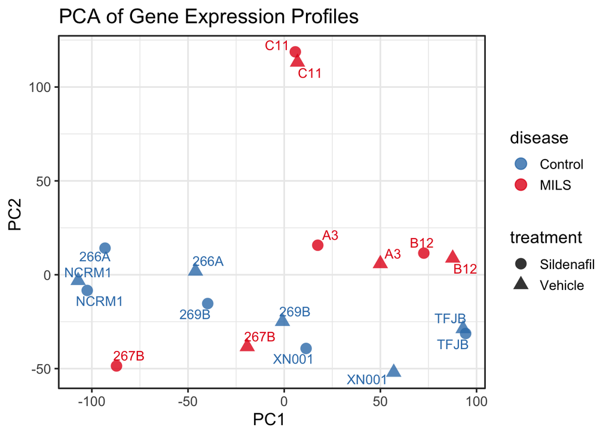

```r
pca <- prcomp(t(expr_collapsed_mat), scale.=TRUE)
pca_df <- data.frame(pca$x, meta2)
#variance_explained <- round(100 * pca$sdev^2 / sum(pca$sdev^2), 1)

ggplot(pca_df, aes(PC1, PC2, color=disease, shape=treatment, label = donor)) +
  geom_point(size=4, alpha=0.8) +
  geom_text_repel(show.legend = FALSE) +
  coord_cartesian(clip = "off") +
  scale_color_manual(values=c("Control" = "#377eb8", "MILS" = "#e41a1c")) +
  theme_bw(base_size = 14) +
  labs(title="PCA of Gene Expression Profiles",
       x=paste0("PC1 "),
       y=paste0("PC2 "))
```

### Heatmap of highly variable genes

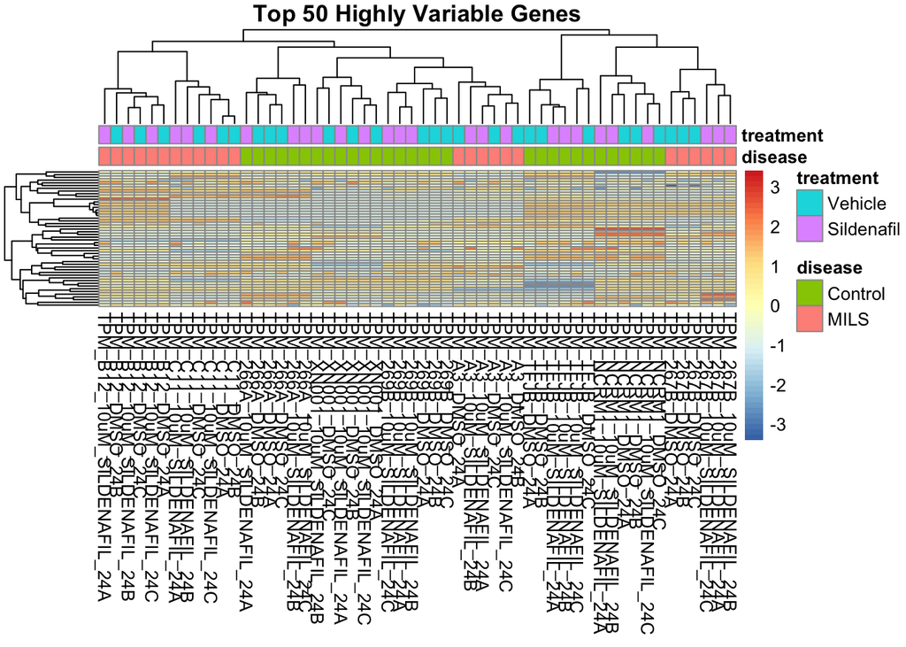

```r
var_genes <- apply(expr_log, 1, var)
top_var <- names(sort(var_genes, decreasing=TRUE))[1:50]

annotation <- metadata[, c("sample", "disease", "treatment")]
rownames(annotation) <- annotation$sample
annotation$sample <- NULL
annotation <- annotation[colnames(expr_log), ]

my_colors <- colorRampPalette(rev(brewer.pal(n = 7, name = "RdYlBu")))(50)

pheatmap(expr_log[top_var, ],
         scale="row",
         color = my_colors,
         show_rownames = FALSE,
         annotation_col = annotation,
         main = "Top 50 Highly Variable Genes")
```

### Donor-Level Drug Response

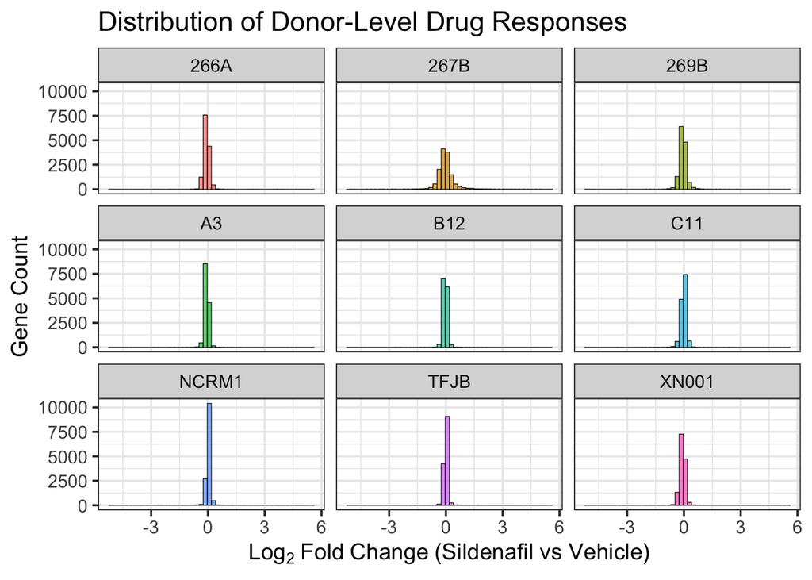

```r
# Convert to wide format to calculate response
donor_pairs <- expr_collapsed %>%
  pivot_wider(names_from = treatment, values_from = expr)

# Calculate Log2FC (Sildenafil - Vehicle mathematically equals Log2(Sildenafil/Vehicle))
donor_pairs$Log2FC <- donor_pairs$Sildenafil - donor_pairs$Vehicle ###

ggplot(donor_pairs, aes(Log2FC, fill=donor)) +
  geom_histogram(bins=50, alpha=0.7, color="black", linewidth = 0.2) +
  theme_bw(base_size = 14) +
  facet_wrap(~donor) + # Faceting is much cleaner for publication than overlaid histograms
  theme(legend.position = "none") +
  labs(title="Distribution of Donor-Level Drug Responses",
       x=expression(Log[2]~Fold~Change~"(Sildenafil vs Vehicle)"),
       y="Gene Count")
```

## 4. Preliminary Results

### Differential Expression Analysis of Disease-Specific Drug Responses

The transcriptional responses to Sildenafil treatment were eveluated in both Control and MILS donor cells utilizing paired linear models, which effectively accounted for baseline donor-specific variability. Because no individual genes reached statistical significance following multiple-testing correction (False Discovery Rate [FDR] < 0.05), unadjusted nominal p-values were employed exclusively for exploratory visualization.

### (1) Drug Responses Within Each Disease Group

#### Main-Effect Model for Control and MILS

To assess treatment effects within each disease group, the model was fitted: Expression ∼ Donor + Treatment

```r
# LogFC and p-value
meta2$donor <- factor(meta2$donor)
meta2$treatment <- factor(meta2$treatment, levels = c("Vehicle","Sildenafil"))

fit <- apply(expr_collapsed_mat, 1, function(gene){
  df <- meta2
  df$y <- as.numeric(gene)
  model <- lm(y ~ donor + treatment, data=df)
  res <- coef(summary(model))

  if("treatmentSildenafil" %in% rownames(res)){
    c(logFC = res["treatmentSildenafil", "Estimate"],
      pvalue = res["treatmentSildenafil", "Pr(>|t|)"])
  } else {
    c(logFC = NA, pvalue = NA)
  }
})

# Paired linear model (drug effect)
metadata_CTRL <- meta2[meta2$disease=="Control", ]
metadata_MILS <- meta2[meta2$disease=="MILS", ]

expr_CTRL <- expr_collapsed_mat[, meta2$disease=="Control"]
expr_MILS <- expr_collapsed_mat[, meta2$disease=="MILS"]

## Differential expression (Control)
fit_CTRL <- apply(expr_CTRL, 1, function(gene){

  df <- metadata_CTRL
  df$y <- as.numeric(gene)

  model <- lm(y ~ donor + treatment, data=df)

  res <- coef(summary(model))

  c(logFC=res["treatmentSildenafil","Estimate"],
    pvalue=res["treatmentSildenafil","Pr(>|t|)"])
})

fit_CTRL <- t(fit_CTRL)

DE_CTRL <- data.frame(
  gene=rownames(expr_CTRL),
  logFC=fit_CTRL[,1],
  pvalue=fit_CTRL[,2]
)

DE_CTRL$padj <- p.adjust(DE_CTRL$pvalue,"BH")

## Differential expression (MILS)
fit_MILS <- apply(expr_MILS, 1, function(gene){

  df <- metadata_MILS
  df$y <- as.numeric(gene)

  model <- lm(y ~ donor + treatment, data=df)

  res <- coef(summary(model))

  c(logFC=res["treatmentSildenafil","Estimate"],
    pvalue=res["treatmentSildenafil","Pr(>|t|)"])
})

fit_MILS <- t(fit_MILS)

DE_MILS <- data.frame(
  gene=rownames(expr_MILS),
  logFC=fit_MILS[,1],
  pvalue=fit_MILS[,2]
)

DE_MILS$padj <- p.adjust(DE_MILS$pvalue,"BH")
```

### Volcano Plot Analysis

To visualize Sildenafil-induced alterations in gene expression, volcano plots were generated independently for both the Control and MILS groups. Given that no genes surpassed the FDR correction threshold, these plots utilize nominal p-values to highlight transcripts exhibiting the most pronounced responses to treatment. Putative significance was defined by a nominal p-value < 0.05 and an absolute log2 fold change (|log2FC|) > 0.5. Applying these criteria, the Control group exhibited one upregulated gene, whereas the MILS cohort demonstrated one upregulated and one downregulated gene.

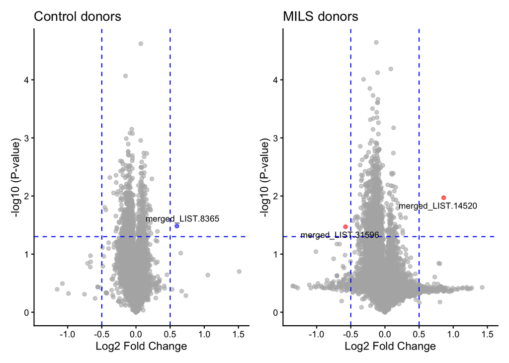

```r
DE <- data.frame(gene=rownames(expr_collapsed_mat), logFC=fit[1,], pvalue=fit[2,])
DE$padj <- p.adjust(DE$pvalue, "BH")
DE$logP <- -log10(DE$pvalue)
#sum(DE$padj < 0.05) #[0]
#sum(DE$logP > -log10(0.05)) #2699

DE_CTRL$logP <- -log10(DE_CTRL$pvalue)
DE_CTRL$signif <- abs(DE_CTRL$logFC) > 0.5 & DE_CTRL$pvalue <0.05

DE_MILS$logP <- -log10(DE_MILS$pvalue)
DE_MILS$signif <- abs(DE_MILS$logFC) > 0.5 & DE_MILS$pvalue <0.05

# Calculate global axis limits across both datasets for perfect comparison
min_x <- min(c(DE_CTRL$logFC, DE_MILS$logFC), na.rm = TRUE)
max_x <- max(c(DE_CTRL$logFC, DE_MILS$logFC), na.rm = TRUE)
min_y <- min(c(DE_CTRL$logP, DE_MILS$logP), na.rm = TRUE)
max_y <- max(c(DE_CTRL$logP, DE_MILS$logP), na.rm = TRUE)

# Control Plot (p1)
p1 <- ggplot(DE_CTRL, aes(x = logFC, y = logP)) +
  geom_point(aes(color = signif), alpha = 0.6) +
  scale_color_manual(values = c("grey70", "blue")) +
  geom_vline(xintercept = c(-0.5, 0.5), linetype = "dashed", color = "blue") +
  geom_hline(yintercept = -log10(0.05), linetype = "dashed", color = "blue") +
  geom_text_repel(
    # FIX: Explicit mathematical subsetting to avoid the logical error
    data = subset(DE_CTRL, signif),
    aes(label = gene),
    size = 3,
    max.overlaps = 15 # Helps prevent errors if there are too many labels
  ) +
  theme_classic() +
  labs(
    title = "Control donors",
    x = "Log2 Fold Change",
    y = "-log10 (P-value)"
  ) +
  theme(legend.position = "none") +
  coord_cartesian(xlim = c(min_x, max_x), ylim = c(min_y, max_y))

# 3. MILS Plot (p2)
p2 <- ggplot(DE_MILS, aes(x = logFC, y = logP)) +
  geom_point(aes(color = signif), alpha = 0.6) +
  scale_color_manual(values = c("grey70", "red")) +
  geom_vline(xintercept = c(-0.5, 0.5), linetype = "dashed", color = "blue") +
  geom_hline(yintercept = -log10(0.05), linetype = "dashed", color = "blue") +
  geom_text_repel(
    # FIX: Explicit mathematical subsetting to avoid the logical error
    data = subset(DE_MILS, signif),
    aes(label = gene),
    size = 3,
    max.overlaps = 15 # Helps prevent errors if there are too many labels
  ) +
  theme_classic() +
  labs(
    title = "MILS donors",
    x = "Log2 Fold Change",
    y = "-log10 (P-value)"
  ) +
  theme(legend.position = "none") +
  coord_cartesian(xlim = c(min_x, max_x), ylim = c(min_y, max_y))

# 4. Print the plots side-by-side
p1 + p2
```

### Scatter Plot Comparision of Control vs MILS Drug Effects

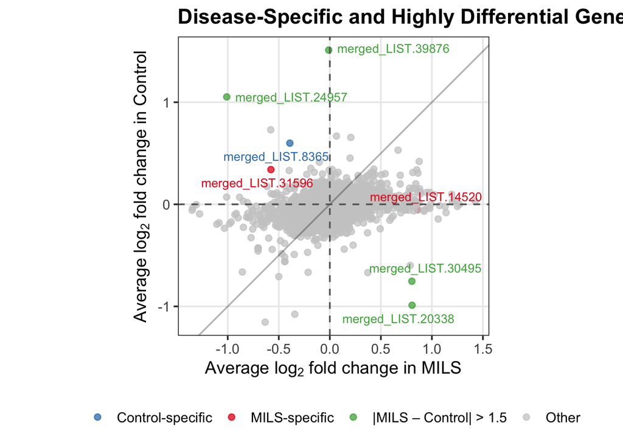

```r
DE_compare <- merge(
  DE_CTRL[,c("gene","logFC","padj")],
  DE_MILS[,c("gene","logFC","padj")],
  by="gene",
  suffixes=c("_CTRL","_MILS")
)
# Define gene groups

sig_CTRL_genes <- DE_CTRL$gene[DE_CTRL$signif]
sig_MILS_genes <- DE_MILS$gene[DE_MILS$signif]
top_genes <- DE_compare$gene[
  abs(DE_compare$logFC_CTRL - DE_compare$logFC_MILS) > 1.5
]


# Annotate genes
DE_compare <- DE_compare %>%
  mutate(
    Highlight = case_when(
      gene %in% sig_CTRL_genes ~ "Control-specific",
      gene %in% sig_MILS_genes ~ "MILS-specific",
      gene %in% top_genes ~ "|MILS – Control| > 1.5",
      TRUE ~ "Other"
    )
  )

DE_compare$Highlight <- factor(
  DE_compare$Highlight,
  levels = c(
    "Control-specific",
    "MILS-specific",
    "|MILS – Control| > 1.5",
    "Other"
  )
)

# Scatter plot
p <- ggplot(DE_compare,
            aes(x = logFC_MILS,
                y = logFC_CTRL,
                color = Highlight)) +

  geom_point(alpha = 0.75, size = 2) +

  # reference lines
  geom_abline(slope = 1, intercept = 0,
              linetype = "solid",
              color = "black",
              alpha = 0.3) +

  geom_vline(xintercept = 0,
             linetype = "dashed",
             color = "grey40") +

  geom_hline(yintercept = 0,
             linetype = "dashed",
             color = "grey40") +

  # label important genes
  geom_text_repel(
    data = dplyr::filter(DE_compare, Highlight != "Other"),
    aes(label = gene),
    size = 3.5,
    max.overlaps = 30,
    box.padding = 0.4,
    point.padding = 0.3,
    show.legend = FALSE
  )+

  scale_color_manual(values = c(
    "MILS-specific" = "#e41a1c",
    "Control-specific" = "#377eb8",
    "|MILS – Control| > 1.5" = "#4daf4a",
    "Other" = "grey80"
  )) +

  coord_equal() +

  theme_bw(base_size = 14) +

  theme(
    legend.position = "bottom",
    legend.title = element_text(face = "bold"),
    plot.title = element_text(face = "bold"),
    panel.grid.minor = element_blank()
  ) +

  labs(
    x = expression("Average log"[2]*" fold change in MILS"),
    y = expression("Average log"[2]*" fold change in Control"),
    title = "Disease-Specific and Highly Differential Genes",
    color = NULL
  )
p
```

### Summary of Highlighted Disease-Specific and Highly Differential Genes

```r
highlighted_genes <- DE_compare %>%
  filter(Highlight != "Other")

gene_dictionary <- data %>%
  select(Gene_ID, Gene_Name) %>%
  distinct()

highlighted_table <- highlighted_genes %>%
  left_join(gene_dictionary, by = c("gene" = "Gene_ID")) %>%
  rename(gene_name = Gene_Name) %>%
  relocate(gene_name, .after = gene) %>%
  arrange(Highlight)


kable(highlighted_table, caption = "Summary of Highlighted Disease-Specific and Highly Differential Genes")
```

Summary of Highlighted Disease-Specific and Highly Differential Genes

| gene | gene_name | logFC_CTRL | padj_CTRL | logFC_MILS | padj_MILS | Highlight |
| --- | --- | --- | --- | --- | --- | --- |
| merged_LIST.8365 | MIR6747 | 0.5991721 | 0.4978215 | -0.3917755 | 0.7659721 | Control-specific |
| merged_LIST.14520 | ENSG00000293955 | -0.0525224 | 0.9548189 | 0.8599976 | 0.6666704 | MILS-specific |
| merged_LIST.31596 | ENSG00000287967 | 0.3403453 | 0.5572673 | -0.5771381 | 0.6666704 | MILS-specific |
| merged_LIST.20338 | ENSG00000291063 | -0.9886909 | 0.6853768 | 0.8059100 | 0.8482513 | \|MILS – Control\| > 1.5 |
| merged_LIST.24957 | ENSG00000305635 | 1.0521678 | 0.5189389 | -1.0100668 | 0.6732048 | \|MILS – Control\| > 1.5 |
| merged_LIST.30495 | ENSG00000274868 | -0.7534786 | 0.6958721 | 0.8036447 | 0.6866497 | \|MILS – Control\| > 1.5 |
| merged_LIST.39876 | ENSG00000309609 | 1.5110573 | 0.5055674 | -0.0109441 | 0.8719508 | \|MILS – Control\| > 1.5 |

### (2) Disease-Specific Response to Sildenafil Treatment

To determine whether transcriptional responses to Sildenafil diverged based on disease state, the interaction between disease status and the treatment intervention was evaluated.

#### Interaction Model

The following model was fitted across all samples: Expression ∼ Donor + Disease + Treatment + Disease:Treatment

The interaction term (Disease:Treatment) specifically tests whether the magnitude or direction of the Sildenafil-induced transcriptional changes significantly differ between the Control and MILS groups.

```r
fit_interaction <- apply(expr_collapsed_mat, 1, function(gene){
  df <- meta2
  df$y <- as.numeric(gene)

  model <- lm(y ~ donor + treatment + disease:treatment, data=df)
  res <- coef(summary(model))

  # DYNAMIC SEARCH: Find any term name in the summary that contains a colon ":" <- because the order matter.
  inter_term <- grep(":", rownames(res), value = TRUE)

  # If an interaction term was successfully generated and kept by the model:
  if(length(inter_term) > 0){
      c(interaction = res[inter_term[1], "Estimate"],
        pvalue = res[inter_term[1], "Pr(>|t|)"])
  } else {
      # If lm() dropped the term entirely (e.g., due to singularities)
      c(interaction = NA, pvalue = NA)
  }
})

# Transpose the matrix
fit_interaction <- t(fit_interaction)

# Build the dataframe
DE_interaction <- data.frame(
    gene = rownames(expr_collapsed_mat),
    effect = fit_interaction[,1],
    pvalue = fit_interaction[,2]
)

# Strip the row names so the kable output doesn't visually shift
rownames(DE_interaction) <- NULL

# Calculate adjusted p-values
DE_interaction$padj <- p.adjust(DE_interaction$pvalue, "BH")
```

#### Top 10 Interaction Genes

To identify the most robust candidates for disease-specific drug responses, transcripts were ranked according to the nominal p-value of the interaction term, and the top ten genes were selected for further visualization. Among these, RBX1, MT-ND2, and ST3GAL6 exhibited negative interaction coefficients, indicating opposing treatment responses between the Control and MILS groups. Interestingly, MT-ND2 is encoded by mitochondrial DNA and is intrinsically linked to MILS pathogenesis; therefore, its differential modulation by Sildenafil is of particular interest and warrants further mechanistic investigation. The remaining seven candidates displayed positive interaction coefficients. However, because the adjusted p-values (padj) for these interaction terms remained high, these results should be interpreted as exploratory, highlighting a need for future functional validation to confirm these disease-specific gene expression.

```r
# Top interaction genes
top_interaction <- DE_interaction %>%
  arrange(pvalue) %>%
  head(10)

# Extract a clean, unique mapping dictionary from your original dataset
gene_dictionary <- data %>%
  select(Gene_ID, Gene_Name) %>%
  distinct()

# Join the mapping to your top_interaction dataframe
top_interaction <- top_interaction %>%
  left_join(gene_dictionary, by = c("gene" = "Gene_ID")) %>%
  rename(gene_name = Gene_Name) %>%
  relocate(gene_name, .after = gene)

kable(top_interaction, caption="Top 10 Disease-Specific Response Genes")
```

Top 10 Disease-Specific Response Genes

| gene | gene_name | effect | pvalue | padj |
| --- | --- | --- | --- | --- |
| merged_LIST.31956 | ENSG00000289841 | 0.3101701 | 0.0000450 | 0.6206337 |
| merged_LIST.17234 | PRKXP1 | 0.4182087 | 0.0001599 | 0.9421256 |
| merged_LIST.25525 | ZNF837 | 0.3541910 | 0.0003902 | 0.9421256 |
| merged_LIST.30361 | ARFGAP1 | 0.1590313 | 0.0005795 | 0.9421256 |
| merged_LIST.31937 | RBX1 | -0.1666585 | 0.0006414 | 0.9421256 |
| merged_LIST.49317 | MT-ND2 | -0.3105833 | 0.0006490 | 0.9421256 |
| merged_LIST.21925 | HGS | 0.1546860 | 0.0011579 | 0.9421256 |
| merged_LIST.33506 | ST3GAL6 | -0.1945768 | 0.0011944 | 0.9421256 |
| merged_LIST.18284 | STX4 | 0.2002897 | 0.0012205 | 0.9421256 |
| merged_LIST.15179 | ENSG00000241494 | 0.3574383 | 0.0013788 | 0.9421256 |

#### Trajectories of the Top 6 Interaction Genes

To visualize individual donor responses for the top interaction candidates, spaghetti plots were generated to track gene expression trajectories across treatment conditions. An analysis of the log₂(TPM+1) expression values revealed highly consistent treatment-induced changes (slopes) among the MILS donors, underscoring a uniform transcriptional response to Sildenafil within this disease group. Especially, the expression trajectory of MT-ND2 (merged_LIST.49317) demonstrated a distinctly opposite pattern, exhibiting Sildenafil-induced upregulation in the MILS group alongside a concomitant downregulation in the Control group.

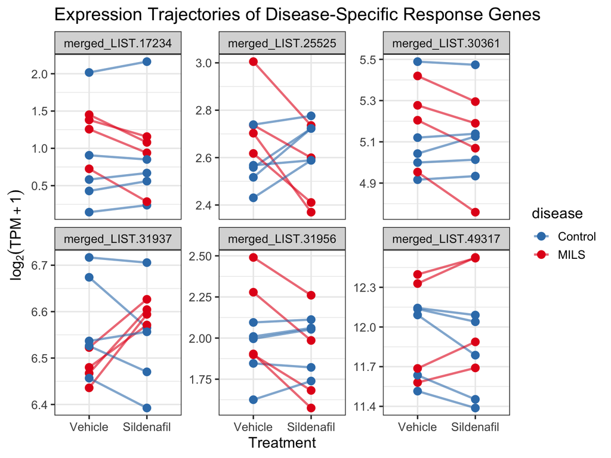

```r
# Get top 6 genes from the interaction model
top6_genes <- DE_interaction %>%
  arrange(pvalue) %>%
  head(6)

# Build a simple map of donor to disease to avoid the previous error
disease_map <- meta2 %>% select(donor, disease) %>% distinct()

# Filter expression data and join the disease map
expr_plot <- expr_collapsed %>%
  filter(gene %in% top6_genes$gene) %>%
  left_join(disease_map, by="donor")

# Plot the data
ggplot(expr_plot, aes(treatment, expr, group=donor, color=disease)) +
  geom_line(alpha=0.6, linewidth=1) +
  geom_point(size=3) +
  scale_color_manual(values=c("Control" = "#377eb8", "MILS" = "#e41a1c")) +
  facet_wrap(~gene, scales="free_y", nrow=2, ncol=3) +
  theme_bw(base_size = 14) +
  labs(y=expression(log[2](TPM+1)),
       x="Treatment",
       title="Expression Trajectories of Disease-Specific Response Genes")
```

#### Scatter plot Visualization of Top 10 Interaction Genes

To further contextualize the top ten interaction genes, their respective treatment effects were mapped onto the comparative Control versus MILS scatter plot. Consistent with the elevated adjusted p-values observed in the interaction model, all ten candidates localized to the central, non-significant region of the plot. None of these transcripts exceeded the previously established absolute log₂ fold change threshold of 1.5, underscoring that while these genes exhibit the strongest relative interaction effects in this dataset, the absolute magnitude of their transcriptional shifts remains modest.

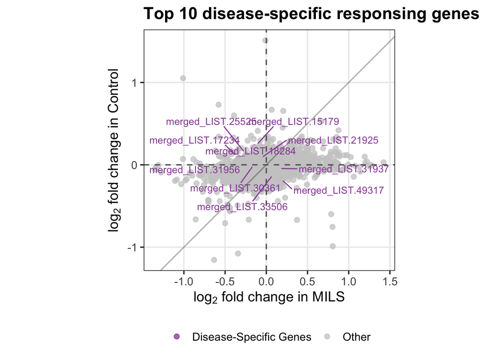

```r
# Define gene groups
highlight_genes <- top_interaction$gene

# Annotate genes
DE_compare <- DE_compare %>%
  mutate(
    Highlight = case_when(
      gene %in% highlight_genes ~ "Disease-Specific Genes",
      TRUE ~ "Other"
    )
  )


# Scatter plot- Top 10 Disease-Specific Response Genes
p1 <- ggplot(DE_compare,
            aes(x = logFC_MILS,
                y = logFC_CTRL,
                color = Highlight)) +

  geom_point(alpha = 0.75, size = 2) +

  # reference lines
  geom_abline(slope = 1, intercept = 0,
              linetype = "solid",
              color = "black",
              alpha = 0.3) +

  geom_vline(xintercept = 0,
             linetype = "dashed",
             color = "grey40") +

  geom_hline(yintercept = 0,
             linetype = "dashed",
             color = "grey40") +

  # label important genes
  geom_text_repel(
    data = dplyr::filter(DE_compare, Highlight != "Other"),
    aes(label = gene),
    size = 3.5,
    max.overlaps = 30,
    box.padding = 0.4,
    point.padding = 0.3,
    show.legend = FALSE
  )+

  scale_color_manual(values = c(
    "Disease-Specific Genes" = "#984ea3",
    "Other" = "grey80"
  )) +

  coord_equal() +

  theme_bw(base_size = 14) +

  theme(
    legend.position = "bottom",
    legend.title = element_text(face = "bold"),
    plot.title = element_text(face = "bold"),
    panel.grid.minor = element_blank()
  ) +

  labs(
    x = expression("log"[2]*" fold change in MILS"),
    y = expression("log"[2]*" fold change in Control"),
    title = "Top 10 disease-specific responsing genes",
    color = NULL
  )
p1
```

## 5. Conclusions

A comprehensive gene expression analysis was conducted to evaluate the transcriptional response to Sildenafil treatment in Control and MILS donor-derived iPSC-NPCs. Exploratory analyses, including principal component analysis (PCA) and hierarchical clustering (heatmaps), revealed that global expression patterns clustered primarily by donor and disease status rather than by treatment. This suggests significant inter-individual heterogeneity in drug response. This variability is particularly pronounced among MILS donors; although they share mutations within the MT-ATP6 gene, the specific positions of these point mutations often vary, which may contribute to divergent baseline phenotypes and treatment responses (Zink et al., 2026).

Subsequent differential expression analyses visualized via volcano and scatter plots identified several genes exhibiting modest treatment-associated changes, though no transcripts retained statistical significance following multiple testing correction (FDR < 0.05). Despite these statistical limitations, the distinct MILS-specific upregulation of MT-ND2 emerges as a compelling candidate for future mechanistic research. Furthermore, the pronounced transcriptional shifts observed uniquely in MILS donor 267B following Sildenafil administration highlight the need for targeted investigations into donor-specific factors that may modulate drug efficacy. Overall, these preliminary findings suggest that Sildenafil induces modest transcriptional alterations in this model. Future studies employing larger cohorts will be essential to robustly delineate and validate these disease-specific pharmacological effects.

## 6. Reference

1. McCormick, E. M. et al. Expert Panel Curation of 113 Primary Mitochondrial Disease Genes for the Leigh Syndrome Spectrum. Ann Neurol 94, 696–712 (2023).
2. Percival, J. M., Siegel, M. P., Knowels, G. & Marcinek, D. J. Defects in mitochondrial localization and ATP synthesis in the mdx mouse model of Duchenne muscular dystrophy are not alleviated by PDE5 inhibition. Human Molecular Genetics 22, 153–167 (2013).
3. Zink, A. et al. Pluripotent stem-cell-based screening uncovers sildenafil as a mitochondrial disease therapy. Cell 0, (2026)